# ANA 1005: Enterprise Analytics Final Assignment

The study is about a dataset containing shopping information from 10 different shopping malls in Istanbul between 2021 and 2023.  
The goal is to perform exploratory data analysis to identify shopping trends and patterns in Istanbul, and to generate actionable insights for the intended audience.  
The audience's needs include identifying customers' spending behavior based on demographic factors like age and gender, determining customers' preferred payment methods, and identifying the best-performing shopping malls in Istanbul.

Data Dictionary:

Invoice no: Invoice number. Nominal. A combination of the letter 'I' and a 6-digit integer is uniquely assigned to each operation.

Customer Id: Customer number. Nominal. A combination of the letter 'C' and a 6-digit integer is uniquely assigned to each operation.

Gender: String variable of the customer's gender.

Age: Positive Integer variable of the customer’s age.

Category: String variable of the category of the purchased product.

Quantity: The quantity of each product (item) per transaction. Numeric.

Price: Unit price. Numeric. Product price per unit in Turkish Liras (TL).

Payment Method: String variable of the payment method (cash, credit card or debit card) used for the transaction.

Invoice Date: The day when a transaction was generated.

Shopping Mall: String variable of the name of the shopping mall where the transaction was made

## Part 1: Exploratory Analysis

#### 1(a): Using descriptive statistics and visualizations (e.g., histograms, box plots, scatter plots) to understand the distribution, variability, and relationships between variables

```python
# import all libraries here
import pandas as pd
import numpy as np
import matplotlib.pyplot as plt
import seaborn as sns
from scipy import stats
from scipy.stats import norm, kurtosis
from statsmodels.graphics.gofplots import qqplot
```

```python
main_df = pd.read_csv("customer_shopping_data.csv")
df = main_df.copy() #creating a copy to investigate the orignal data after pre-processing
df.head()
```

|  | invoice_no | customer_id | gender | age | category | quantity | price | payment_method | invoice_date | shopping_mall |
| --- | --- | --- | --- | --- | --- | --- | --- | --- | --- | --- |
| 0 | I138884 | C241288 | Female | 28.0 | Clothing | 5 | 1500.40 | Credit Card | 05-08-2022 | Kanyon |
| 1 | I317333 | C111565 | Male | 21.0 | Shoes | 3 | 1800.51 | Debit Card | 12-12-2021 | Forum Istanbul |
| 2 | I127801 | C266599 | Male | 20.0 | Clothing | 1 | 300.08 | Cash | 09-11-2021 | Metrocity |
| 3 | I173702 | C988172 | Female | 66.0 | Shoes | 5 | 3000.85 | Credit Card | 16-05-2021 | Metropol AVM |
| 4 | I337046 | C189076 | Female | 53.0 | Books | 4 | 60.60 | Cash | 24-10-2021 | Kanyon |

```python
# identify the shape of the data
print(f"Number of rows: {df.shape[0]}")
print(f"Number of columns: {df.shape[1]}")
```

```
Number of rows: 99457
Number of columns: 10
```

```python
# adding a total sales column
df["total_sale"] = df["quantity"]*df["price"]
df.head()
```

|  | invoice_no | customer_id | gender | age | category | quantity | price | payment_method | invoice_date | shopping_mall | total_sale |
| --- | --- | --- | --- | --- | --- | --- | --- | --- | --- | --- | --- |
| 0 | I138884 | C241288 | Female | 28.0 | Clothing | 5 | 1500.40 | Credit Card | 05-08-2022 | Kanyon | 7502.00 |
| 1 | I317333 | C111565 | Male | 21.0 | Shoes | 3 | 1800.51 | Debit Card | 12-12-2021 | Forum Istanbul | 5401.53 |
| 2 | I127801 | C266599 | Male | 20.0 | Clothing | 1 | 300.08 | Cash | 09-11-2021 | Metrocity | 300.08 |
| 3 | I173702 | C988172 | Female | 66.0 | Shoes | 5 | 3000.85 | Credit Card | 16-05-2021 | Metropol AVM | 15004.25 |
| 4 | I337046 | C189076 | Female | 53.0 | Books | 4 | 60.60 | Cash | 24-10-2021 | Kanyon | 242.40 |

```python
# identify if the data has any null values
print(df.isnull().sum())
```

```
invoice_no           0
customer_id          0
gender               0
age               3683
category             0
quantity             0
price                0
payment_method       0
invoice_date         0
shopping_mall        0
total_sale           0
dtype: int64
```

```python
# treating missing values (since only less than 10% of the total data is missing, we will impute it using the mean)
mean_age = df['age'].mean()
df['age'] = df['age'].fillna(mean_age)
```

```python
# validate if the data has any null values
print(df.isnull().sum())
```

```
invoice_no        0
customer_id       0
gender            0
age               0
category          0
quantity          0
price             0
payment_method    0
invoice_date      0
shopping_mall     0
total_sale        0
dtype: int64
```

```python
# identify the data type
print(df.dtypes)
```

```
invoice_no         object
customer_id        object
gender             object
age               float64
category           object
quantity            int64
price             float64
payment_method     object
invoice_date       object
shopping_mall      object
total_sale        float64
dtype: object
```

```python
# converting the data according to suitable data type
df['age'] = df['age'].astype(int)
```

```python
# validate the data type
print(df.dtypes)
```

```
invoice_no         object
customer_id        object
gender             object
age                 int32
category           object
quantity            int64
price             float64
payment_method     object
invoice_date       object
shopping_mall      object
total_sale        float64
dtype: object
```

```python
# identify the unique values in our data set
df.apply(lambda df:len(df.unique()))
```

```
invoice_no        99457
customer_id       99457
gender                2
age                  52
category              8
quantity              5
price               793
payment_method        3
invoice_date        797
shopping_mall        10
total_sale          816
dtype: int64
```

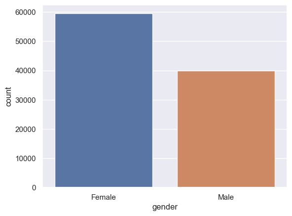

```python
sns.countplot(x='gender', data=df)
plt.show()
```

Using a countplot we can identify the demograpy distribution for gender, it also suggests that:

The mall's in Istanbul likely have more products that cater to the needs of a female shopper

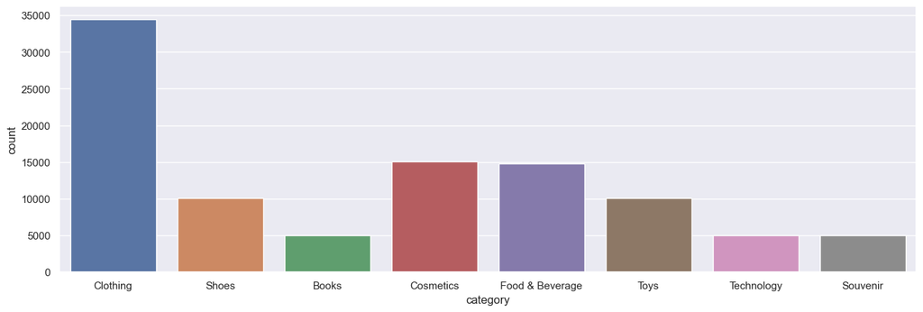

```python
plt.figure(figsize=(16, 5))
sns.countplot(x="category", data=df)
plt.show()
```

The countplot above helps us in identifying the distribution of category:

Clothing is the most available/ common product sold in the malls

Cosmetics and Food & Beverages are the next most common category of products sold with Cosmetics being sold slightly more than Food & Beverage

Using this information, we can identify who purchases what products more.

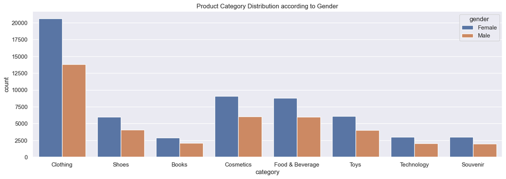

```python
plt.figure(figsize=(16, 5))
sns.countplot(x='category', hue='gender', data=df)
plt.title('Product Category Distribution according to Gender')
plt.show()
```

The chart above help us identify: Females shop more than Males

Clothing is the most sold product which is highly purchased by females

In all the category, females are likely to purchase more than males

We can now identify what is the most preferred method of payment since we now know who spends/ purchases more.

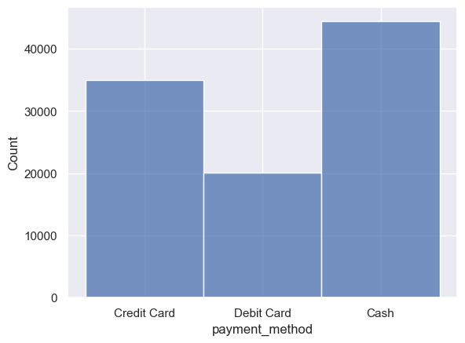

```python
sns.histplot(df['payment_method'])
plt.show()
```

Using the histogram we can identify that:

Cash is the most preferred method of payment

Nearly only half of the customers prefer paying via Debit card as compared to customers paying in cash

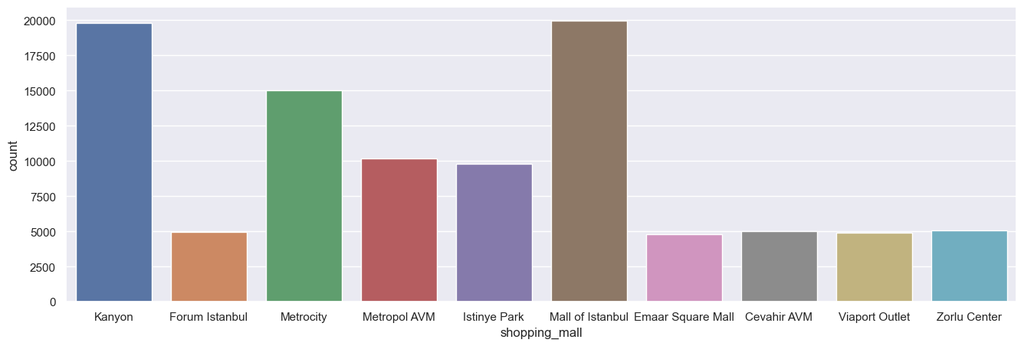

```python
plt.figure(figsize=(16, 5))
sns.countplot(x="shopping_mall", data=df)
plt.show()
```

From the above countplot, we can identify:

Kanyon and Mall of Istanbul are among the two leading malls in Istanbul based on the sales

This information along with the payment method information can help us identify if any mall has preference over a specific method of payment

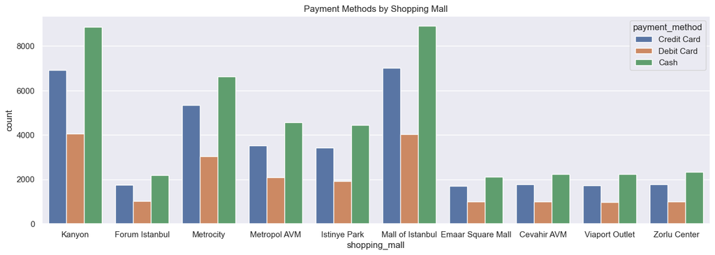

```python
plt.figure(figsize=(16, 5))
sns.countplot(x='shopping_mall', hue='payment_method', data=df)
plt.title('Payment Methods by Shopping Mall')
plt.show()
```

From the above chart we can identify that:

All the malls accept all the three payment method

It can also be verified here that "cash" is the most preferred method of payment

#### 1(b). Identifying KPI's

```python
# total sales for each shopping mall
total_sales_by_mall = df.groupby('shopping_mall')['total_sale'].sum()

print("Total Sales by Shopping Mall:\n", total_sales_by_mall)
```

```
Total Sales by Shopping Mall:
 shopping_mall
Cevahir AVM          14125804.85
Emaar Square Mall    13709932.21
Forum Istanbul       13660018.33
Istinye Park         28426453.19
Kanyon               57056453.95
Mall of Istanbul     56623797.74
Metrocity            42796535.62
Metropol AVM         28684109.63
Viaport Outlet       14305151.75
Zorlu Center         14509764.89
Name: total_sale, dtype: float64
```

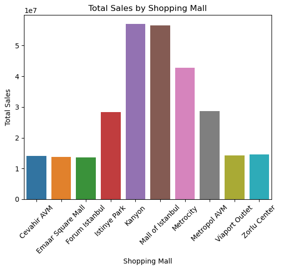

```python
# Create a barplot of total sales by shopping mall
sns.barplot(x=total_sales_by_mall.index, y=total_sales_by_mall.values)
plt.xticks(rotation=45)
plt.xlabel('Shopping Mall')
plt.ylabel('Total Sales')
plt.title('Total Sales by Shopping Mall')
plt.show()
```

The barplot above helps us to identify which mall's have the highest sales and can help in supporting our validation on ranking the mall based on the count.

In both the charts, we can validate that Kanyon and Mall of Istanbul rank among the top Mall's in Istanbul for the data available

In both the charts, Metrocity Mall ranks third based on the count and overall sales

```python
# average price per unit for each category
avg_price_per_unit = df.groupby('category')['price'].mean()

print("\nAverage Price per Unit by Category:\n", avg_price_per_unit)
```

```
Average Price per Unit by Category:
 category
Books               139.944519
Clothing           1018.654721
Cosmetics           240.195977
Food & Beverage     109.848466
Shoes              1921.352610
Souvenir            145.104457
Technology         3259.402322
Toys                219.792462
Name: price, dtype: float64
```

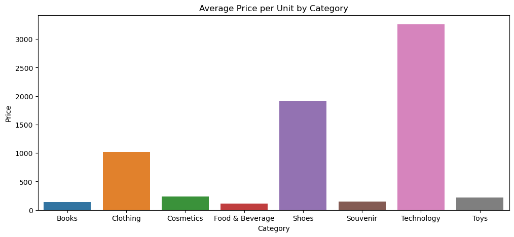

```python
plt.figure(figsize=(12, 5))
sns.barplot(x=avg_price_per_unit.index, y=avg_price_per_unit.values)
plt.title('Average Price per Unit by Category')
plt.xlabel('Category')
plt.ylabel('Price')
plt.show()
```

The chart suggests:

Technology related products have the most highest average price per unit

Clothing which is the most sold product category, has an average price above most of the other categories

```python
# percentage of transactions paid via cash, debit, or credit card
cash_percent = df[df['payment_method'] == 'Cash'].shape[0] / df.shape[0] * 100
debit_card_percent = df[df['payment_method'] == 'Debit Card'].shape[0] / df.shape[0] * 100
credit_card_percent = df[df['payment_method'] == 'Credit Card'].shape[0] / df.shape[0] * 100

print("\nPercentage of Transactions Paid with Cash: {:.2f}%".format(cash_percent))
print("\nPercentage of Transactions Paid with Debit Card: {:.2f}%".format(debit_card_percent))
print("\nPercentage of Transactions Paid with Credit Card: {:.2f}%".format(credit_card_percent))
```

```
Percentage of Transactions Paid with Cash: 44.69%

Percentage of Transactions Paid with Debit Card: 20.19%

Percentage of Transactions Paid with Credit Card: 35.12%
```

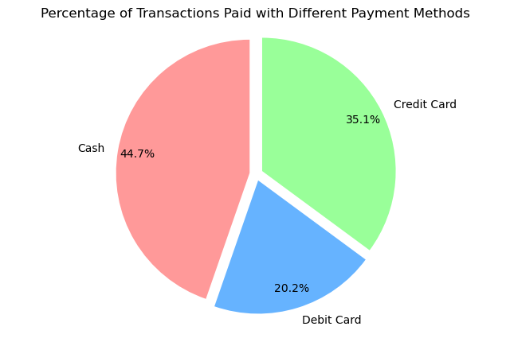

```python
# plot the percentage of transaction via card/ cash
labels = ['Cash', 'Debit Card', 'Credit Card']
sizes = [cash_percent, debit_card_percent, credit_card_percent]
colors = ['#ff9999','#66b3ff','#99ff99']
explode = (0.05, 0.05, 0.05)  # explode 1st and 2nd slice

fig, ax = plt.subplots(figsize=(8, 5))
ax.pie(sizes, colors=colors, labels=labels, autopct='%1.1f%%', startangle=90, pctdistance=0.85, explode=explode)
ax.axis('equal')
plt.title("Percentage of Transactions Paid with Different Payment Methods")
plt.show()
```

The above pie chart can be used to validate our findings from above which states that Cash is the most preferred method of payment in Istanbul

```python
# average age of customers for each shopping mall
avg_age = df.groupby('shopping_mall')['age'].mean()

print("\nAverage Age by Shopping Mall:\n", avg_age)
```

```
Average Age by Shopping Mall:
 shopping_mall
Cevahir AVM          43.164696
Emaar Square Mall    43.531075
Forum Istanbul       43.470386
Istinye Park         43.363153
Kanyon               43.511830
Mall of Istanbul     43.411974
Metrocity            43.468190
Metropol AVM         43.169964
Viaport Outlet       43.212047
Zorlu Center         43.491626
Name: age, dtype: float64
```

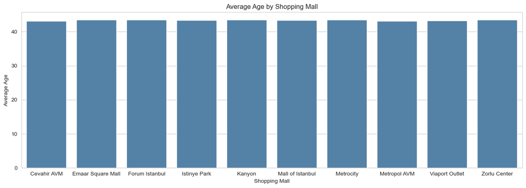

```python
sns.set_style('whitegrid')
plt.figure(figsize=(16, 5))
sns.barplot(x=avg_age.index, y=avg_age.values, color='steelblue')
plt.title('Average Age by Shopping Mall')
plt.xlabel('Shopping Mall')
plt.ylabel('Average Age')
plt.show()
```

Using the chart and data above, we can assume that the average age of consumers at each mall is 43 years

```python
# number of transactions for each category
num_transactions = df['category'].value_counts()

print("\nNumber of Transactions by Category:\n", num_transactions)
```

```
Number of Transactions by Category:
 Clothing           34487
Cosmetics          15097
Food & Beverage    14776
Toys               10087
Shoes              10034
Souvenir            4999
Technology          4996
Books               4981
Name: category, dtype: int64
```

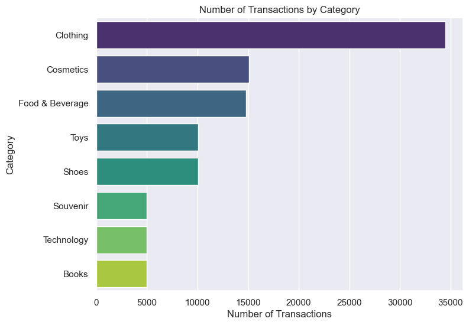

```python
sns.set(style='darkgrid')
plt.figure(figsize=(8, 6))
sns.barplot(x=num_transactions.values, y=num_transactions.index, palette='viridis')

plt.title('Number of Transactions by Category')
plt.xlabel('Number of Transactions')
plt.ylabel('Category')

plt.show()
```

The above chart validates our findings of Clothing being the most selling product among other categories followed by Cosemtics and Food & Beverage

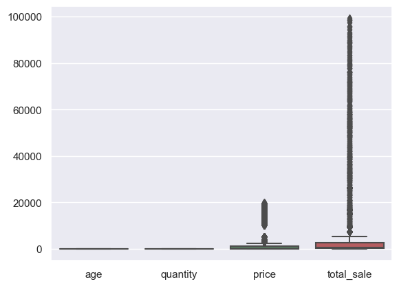

```python
sns.boxplot(data=df)
```

We use the boxplot here to identify if there are any outliers present in our dataset  
We can identify that:

"age" and "quantity" have no visible outliers

"total_sale" and "price" variable has extreme visible ouliers  
This information allows us to check the outliers present in the data

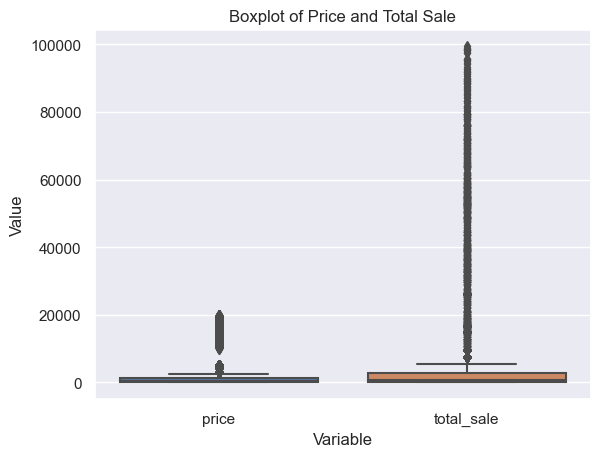

```python
sns.boxplot(data=df[["price", "total_sale"]])
plt.title("Boxplot of Price and Total Sale")
plt.xlabel("Variable")
plt.ylabel("Value")
plt.show()
```

```python
# calculate upper and lower bounds
q1 = df.quantile(0.25)
q3 = df.quantile(0.75)
iqr = q3 - q1
lower_bound = q1 - 1.5 * iqr
upper_bound = q3 + 1.5 * iqr

# count number of outliers in each column
num_outliers = (df < lower_bound) | (df > upper_bound)
num_outliers = num_outliers.sum()
print(num_outliers)
```

```
age                   0
category              0
customer_id           0
gender                0
invoice_date          0
invoice_no            0
payment_method        0
price              5768
quantity              0
shopping_mall         0
total_sale        14664
dtype: int64
```

```python
# calculate IQR and upper/lower bounds for price and total_sale
q1 = df.quantile(0.25)
q3 = df.quantile(0.75)
iqr = q3 - q1
lower_bound = q1 - 1.5 * iqr
upper_bound = q3 + 1.5 * iqr

# replace outliers with upper/lower bounds
df['price'] = np.where(df['price'] > upper_bound['price'], upper_bound['price'], df['price'])
df['price'] = np.where(df['price'] < lower_bound['price'], lower_bound['price'], df['price'])
df['total_sale'] = np.where(df['total_sale'] > upper_bound['total_sale'], upper_bound['total_sale'], df['total_sale'])
df['total_sale'] = np.where(df['total_sale'] < lower_bound['total_sale'], lower_bound['total_sale'], df['total_sale'])
```

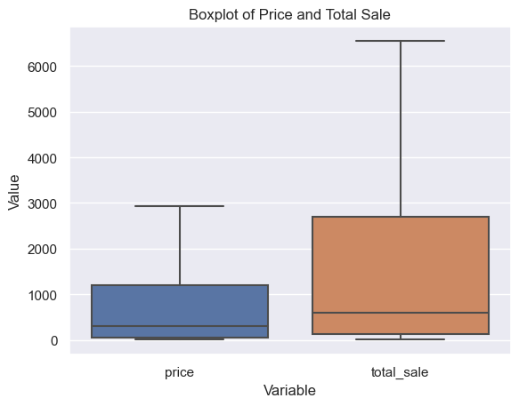

```python
sns.boxplot(data=df[["price", "total_sale"]])
plt.title("Boxplot of Price and Total Sale")
plt.xlabel("Variable")
plt.ylabel("Value")
plt.show()
```

## Part 2: Analyzing the distribution of data

```python
df_dist = df.copy() # creating a copy to analyze the distribution of data
df_dist.head()
```

|  | invoice_no | customer_id | gender | age | category | quantity | price | payment_method | invoice_date | shopping_mall | total_sale |
| --- | --- | --- | --- | --- | --- | --- | --- | --- | --- | --- | --- |
| 0 | I138884 | C241288 | Female | 28 | Clothing | 5 | 1500.400 | Credit Card | 05-08-2022 | Kanyon | 6547.275 |
| 1 | I317333 | C111565 | Male | 21 | Shoes | 3 | 1800.510 | Debit Card | 12-12-2021 | Forum Istanbul | 5401.530 |
| 2 | I127801 | C266599 | Male | 20 | Clothing | 1 | 300.080 | Cash | 09-11-2021 | Metrocity | 300.080 |
| 3 | I173702 | C988172 | Female | 66 | Shoes | 5 | 2932.625 | Credit Card | 16-05-2021 | Metropol AVM | 6547.275 |
| 4 | I337046 | C189076 | Female | 53 | Books | 4 | 60.600 | Cash | 24-10-2021 | Kanyon | 242.400 |

#### 1. Skew and Kurtosis

```python
# inititate dictionaries to store skew and kurtosis of data
skew_dict = {}
kurt_dict = {}

# list of columns to be analyzed
sub_cols = ['age','quantity','price','total_sale']

# calculate skew and kurtosis of each column
for column in sub_cols:
    skew_dict[column] = df_dist[column].skew()
    kurt_dict[column] = df_dist[column].kurtosis()

# print skew and kurtosis of each column
for column in sub_cols:
    print('Skew = ', round(skew_dict[column],5), '| Kurtosis = ', round(kurt_dict[column],5), ' <- ', column)
```

```
Skew =  0.01302 | Kurtosis =  -1.1289  <-  age
Skew =  -0.0013 | Kurtosis =  -1.29589  <-  quantity
Skew =  1.41891 | Kurtosis =  1.20104  <-  price
Skew =  1.03075 | Kurtosis =  -0.57724  <-  total_sale
```

**Skew and Kurtosis interpretation**  
*Note: Pandas' kurtosis function uses Fisher’s definition of kurtosis (kurtosis of normal == 0.0) and produces excess kurtosis as the output. Since the normal distributions have a kurtosis of 3, excess kurtosis is calculated by subtracting kurtosis by 3.*

#### 2. Visual interpretation - Histogram, Boxplot, and QQ plot

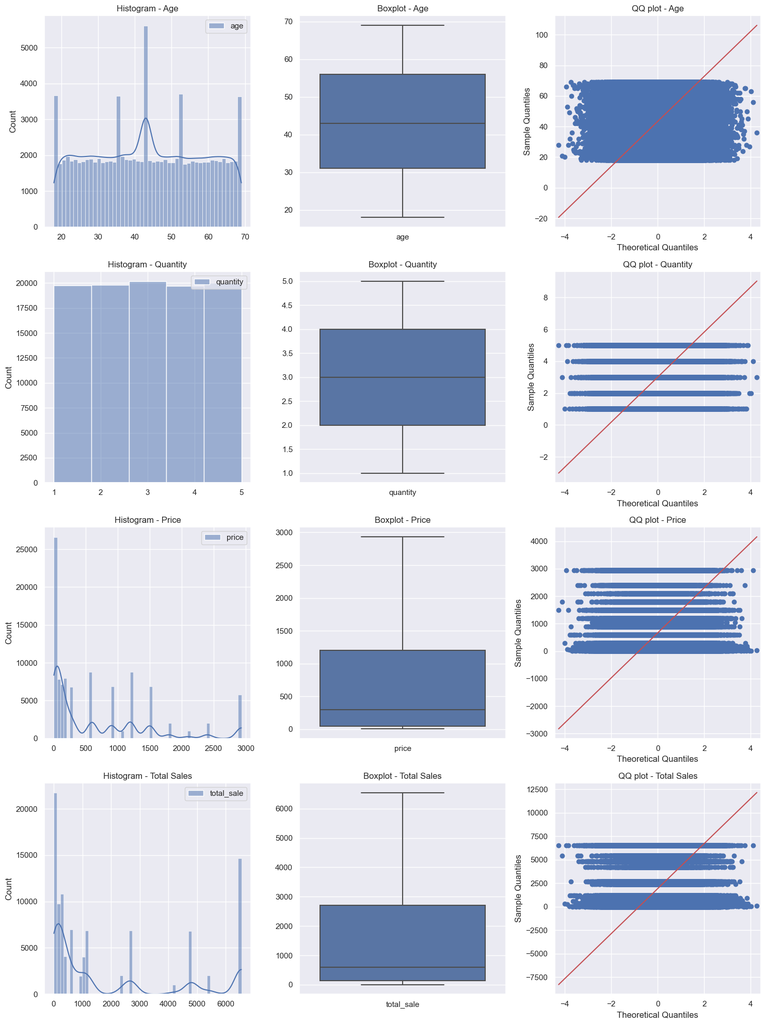

```python
# histogram, boxplot and qqp plot
fig, axs = plt.subplots(nrows=4,ncols=3, figsize=(15,20))

# age
sns.histplot(data=df_dist[['age']], kde=True, ax=axs[0,0])
axs[0,0].set_title('Histogram - Age')
sns.boxplot(data=df_dist[['age']], ax=axs[0,1])
axs[0,1].set_title('Boxplot - Age')
qqplot(data=df_dist[['age']], line='s', ax=axs[0,2])
axs[0,2].set_title('QQ plot - Age')

# quantity
sns.histplot(data=df_dist[['quantity']], kde=False, bins =5, ax=axs[1,0])
axs[1,0].set_title('Histogram - Quantity')
sns.boxplot(data=df_dist[['quantity']], ax=axs[1,1])
axs[1,1].set_title('Boxplot - Quantity')
qqplot(data=df_dist[['quantity']], line='s', ax=axs[1,2])
axs[1,2].set_title('QQ plot - Quantity')

# price
sns.histplot(data=df_dist[['price']], kde=True, ax=axs[2,0])
axs[2,0].set_title('Histogram - Price')
sns.boxplot(data=df_dist[['price']], ax=axs[2,1])
axs[2,1].set_title('Boxplot - Price')
qqplot(data=df_dist[['price']], line='s', ax=axs[2,2])
axs[2,2].set_title('QQ plot - Price')

# total slaes
sns.histplot(data=df_dist[['total_sale']], kde=True, ax=axs[3,0])
axs[3,0].set_title('Histogram - Total Sales')
sns.boxplot(data=df_dist[['total_sale']], ax=axs[3,1])
axs[3,1].set_title('Boxplot - Total Sales')
qqplot(data=df_dist[['total_sale']], line='s', ax=axs[3,2])
axs[3,2].set_title('QQ plot - Total Sales')

fig.tight_layout()
plt.show()
```

#### 3. Test of normality

```python
# inititate dictionaries to store statistic and pvalue of the data calculated using scipy.stats.normaltest
stat_dict = {}
p_dict = {}

# list of columns to be analyzed
sub_cols = ['age','quantity','price','total_sale']

# calculate skew and kurtosis of each column
for column in sub_cols:
    stat_dict[column], p_dict[column] = stats.normaltest(df_dist[column])

# choose alpha value
alpha = 0.05

# print skew and kurtosis of each column
for column in sub_cols:
    print("Normality Test for variable:", column, "=> statistic: ", stat_dict[column], "| p-value: ", p_dict[column])

    # null hypothesis: x comes from a normal distribution
    if p < alpha:
        print("Reject the null hypothesis - ", column ," does not comes from a normal distribution")
    else:
        print("Fail to reject the null hypothesis - ", column ," comes from a normal distribution")
    print("\n")
```

```
Normality Test for variable: age => statistic:  49932.6174503556 | p-value:  0.0
Reject the null hypothesis -  age  does not comes from a normal distribution


Normality Test for variable: quantity => statistic:  345030.9448028458 | p-value:  0.0
Reject the null hypothesis -  quantity  does not comes from a normal distribution


Normality Test for variable: price => statistic:  21718.395456377053 | p-value:  0.0
Reject the null hypothesis -  price  does not comes from a normal distribution


Normality Test for variable: total_sale => statistic:  15181.386704161108 | p-value:  0.0
Reject the null hypothesis -  total_sale  does not comes from a normal distribution
```

"scipy.stats.normaltest" tests the null hypothesis that a sample comes from a normal distribution. It is based on D’Agostino and Pearson’s test that combines skew and kurtosis to produce an omnibus test of normality.

## Part 3: Data Analysis and Inights

In this section, we will answer the below-mentioned problem statements for Istanbul's shopping data across its top ten shopping malls.  
Analysis Period: 2021 -2023

Overview of the performance of Istanbul's top ten shopping malls

Projection of Istanbul's 2024 shopping market

```python
df_ist = df.copy() # creating a copy to analyze the distribution of data
df_ist.head()
```

[output not shown]

### Overview of the performance of Istanbul's top ten shopping malls

#### 1. Which shopping malls generated the most sales?

```python
# total sales for each shopping mall
total_sales_by_mall = df_ist.groupby('shopping_mall', sort = True)['total_sale'].sum()

# sort by sales
total_sales_by_mall = total_sales_by_mall.sort_values(ascending = False)

print("Total Sales by Shopping Mall:\n", total_sales_by_mall)
```

[output not shown]

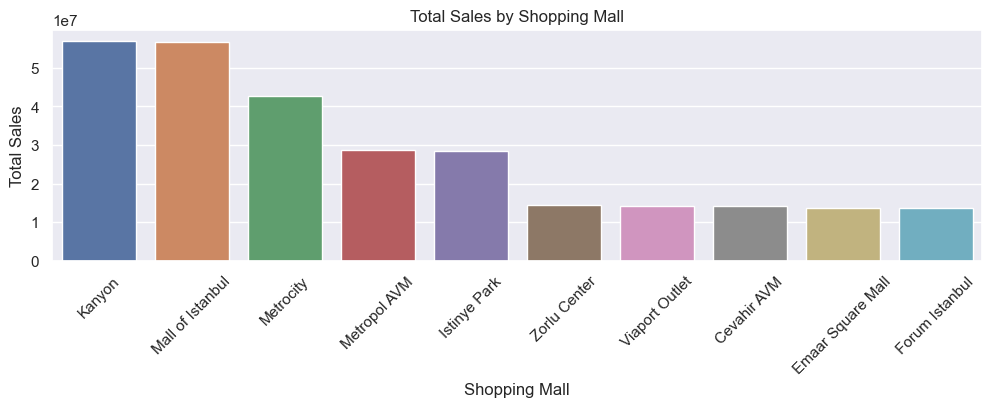

```python
# Create a barplot of total sales by shopping mall
fig, axs = plt.subplots(nrows=1,ncols=1, figsize=(12,3))
sns.barplot(x=total_sales_by_mall.index, \
            y=total_sales_by_mall.values)
plt.xticks(rotation=45)
plt.xlabel('Shopping Mall')
plt.ylabel('Total Sales')
plt.title('Total Sales by Shopping Mall')
plt.show()
```

The top three shopping malls in Istanbul by total sales (in Turkisk Lira) are:

1. Kanyon | Total sales = 57,056,454
2. Mall of Istanbul | Total sales = 56,623,798
3. Metrocity | Total sales = 42,796,536

#### 2. Which shopping categories generate the highest revenue for shopping malls?

```python
# total sales by category across shopping malls
total_sales_by_category = df_ist.groupby('category', sort = True)['total_sale'].sum()

# sort by sales
total_sales_by_category = total_sales_by_category.sort_values(ascending = False)

print("Total Sales by Category:\n", total_sales_by_category)
```

[output not shown]

### Projection of Istanbul's shopping market for the remainder of 2023

```python
import warnings
import itertools
import numpy as np
import matplotlib.pyplot as plt
warnings.filterwarnings("ignore")
plt.style.use('fivethirtyeight')
import pandas as pd
import statsmodels.api as sm
import matplotlib
matplotlib.rcParams['axes.labelsize'] = 14
matplotlib.rcParams['xtick.labelsize'] = 12
matplotlib.rcParams['ytick.labelsize'] = 12
matplotlib.rcParams['text.color'] = 'k'
```

```python
df_proj = df.copy() # creating a copy to analyze the distribution of data
df_proj.head()
```

[output not shown]

```python
# change data type of invoice_date to date format
df_proj['invoice_date'] = pd.to_datetime(df_proj['invoice_date'], format= "%d-%m-%Y" )

# filter datset
df_proj_clean = df_proj[(df_proj['invoice_date'] < '2023-03-01')]

# aggregate sum of sales at date level
total_sales = df_proj_clean.groupby('invoice_date')['total_sale'].sum().reset_index()

# set invoice_date as index
total_sales = total_sales.set_index('invoice_date')

# resample datset to aggregate sales at year-month level istead of day level
total_sales = total_sales['total_sale'].resample('MS').mean()

# plot the data
total_sales.plot(figsize=(10, 5))
plt.show()
```

[output not shown]

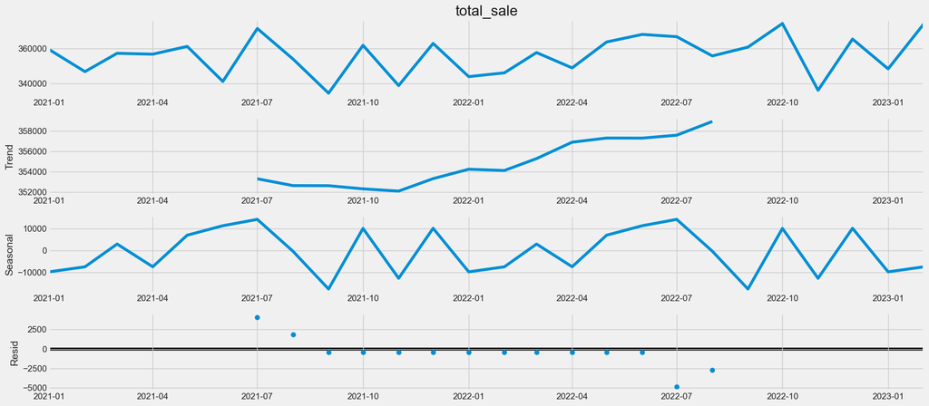

```python
# decompose time series into three distinct components: trend, seasonality, and noise.
from pylab import rcParams
rcParams['figure.figsize'] = 18, 8
decomposition = sm.tsa.seasonal_decompose(total_sales, model='additive')
fig = decomposition.plot()
plt.show()
```

#### Time series forecasting with ARIMA (Autoregressive Integrated Moving Average)

```python
# initiate grid parameters
p = d = q = range(0, 2)
pdq = list(itertools.product(p, d, q))
seasonal_pdq = [(x[0], x[1], x[2], 12) for x in list(itertools.product(p, d, q))]

# use grid search to find the optimal set of parameters that yields the best performance for the model
for param in pdq:
    for param_seasonal in seasonal_pdq:
        try:
            mod = sm.tsa.statespace.SARIMAX(total_sales,
                                            order=param,
                                            seasonal_order=param_seasonal,
                                            enforce_invertibility=False)
            results = mod.fit()
            print('ARIMA{}x{}12 - AIC:{}'.format(param, param_seasonal, results.aic))
        except:
            print('error')
            continue
```

```
ARIMA(0, 0, 0)x(0, 0, 0, 12)12 - AIC:740.528528845654
ARIMA(0, 0, 0)x(0, 0, 1, 12)12 - AIC:741.6541413148171
ARIMA(0, 0, 0)x(0, 1, 0, 12)12 - AIC:308.97131245569057
ARIMA(0, 0, 0)x(0, 1, 1, 12)12 - AIC:310.45306355098865
ARIMA(0, 0, 0)x(1, 0, 0, 12)12 - AIC:651.9356608302539
ARIMA(0, 0, 0)x(1, 0, 1, 12)12 - AIC:655.5357384768905
ARIMA(0, 0, 0)x(1, 1, 0, 12)12 - AIC:313.19183161372365
ARIMA(0, 0, 0)x(1, 1, 1, 12)12 - AIC:311.18665314430365
ARIMA(0, 0, 1)x(0, 0, 0, 12)12 - AIC:774.4696485222404
ARIMA(0, 0, 1)x(0, 0, 1, 12)12 - AIC:771.8758360309309
ARIMA(0, 0, 1)x(0, 1, 0, 12)12 - AIC:310.05703678377273
ARIMA(0, 0, 1)x(0, 1, 1, 12)12 - AIC:310.7305202475471
ARIMA(0, 0, 1)x(1, 0, 0, 12)12 - AIC:768.450143513101
ARIMA(0, 0, 1)x(1, 0, 1, 12)12 - AIC:770.4501434086369
ARIMA(0, 0, 1)x(1, 1, 0, 12)12 - AIC:310.7085858682801
ARIMA(0, 0, 1)x(1, 1, 1, 12)12 - AIC:311.4911136040238
ARIMA(0, 1, 0)x(0, 0, 0, 12)12 - AIC:564.173300813869
ARIMA(0, 1, 0)x(0, 0, 1, 12)12 - AIC:565.6929927039034
ARIMA(0, 1, 0)x(0, 1, 0, 12)12 - AIC:291.8622292710294
ARIMA(0, 1, 0)x(0, 1, 1, 12)12 - AIC:293.6187872605767
ARIMA(0, 1, 0)x(1, 0, 0, 12)12 - AIC:569.1522389028577
ARIMA(0, 1, 0)x(1, 0, 1, 12)12 - AIC:566.7786847308299
ARIMA(0, 1, 0)x(1, 1, 0, 12)12 - AIC:293.55679242465834
ARIMA(0, 1, 0)x(1, 1, 1, 12)12 - AIC:294.5592594398539
ARIMA(0, 1, 1)x(0, 0, 0, 12)12 - AIC:590.049199110538
ARIMA(0, 1, 1)x(0, 0, 1, 12)12 - AIC:591.9104888996454
ARIMA(0, 1, 1)x(0, 1, 0, 12)12 - AIC:292.7698429165711
ARIMA(0, 1, 1)x(0, 1, 1, 12)12 - AIC:294.6003026023116
ARIMA(0, 1, 1)x(1, 0, 0, 12)12 - AIC:591.9178759277282
ARIMA(0, 1, 1)x(1, 0, 1, 12)12 - AIC:593.8536597939194
ARIMA(0, 1, 1)x(1, 1, 0, 12)12 - AIC:294.6043615453332
ARIMA(0, 1, 1)x(1, 1, 1, 12)12 - AIC:295.9237205659093
ARIMA(1, 0, 0)x(0, 0, 0, 12)12 - AIC:594.600567066737
ARIMA(1, 0, 0)x(0, 0, 1, 12)12 - AIC:592.957120069494
ARIMA(1, 0, 0)x(0, 1, 0, 12)12 - AIC:309.7940352611224
ARIMA(1, 0, 0)x(0, 1, 1, 12)12 - AIC:310.28966307229797
ARIMA(1, 0, 0)x(1, 0, 0, 12)12 - AIC:591.4085412696448
ARIMA(1, 0, 0)x(1, 0, 1, 12)12 - AIC:594.7737650643508
ARIMA(1, 0, 0)x(1, 1, 0, 12)12 - AIC:310.26530854873994
ARIMA(1, 0, 0)x(1, 1, 1, 12)12 - AIC:310.86603753397367
```

[output cut: 9 more lines]

```
ARIMA(1, 1, 0)x(0, 0, 1, 12)12 - AIC:570.8788371618876
ARIMA(1, 1, 0)x(0, 1, 0, 12)12 - AIC:292.6754222756245
ARIMA(1, 1, 0)x(0, 1, 1, 12)12 - AIC:294.4871893669456
ARIMA(1, 1, 0)x(1, 0, 0, 12)12 - AIC:570.979143583803
ARIMA(1, 1, 0)x(1, 0, 1, 12)12 - AIC:566.346217310409
ARIMA(1, 1, 0)x(1, 1, 0, 12)12 - AIC:294.4917132609443
ARIMA(1, 1, 0)x(1, 1, 1, 12)12 - AIC:295.6615142105039
ARIMA(1, 1, 1)x(0, 0, 0, 12)12 - AIC:575.5675729187747
ARIMA(1, 1, 1)x(0, 0, 1, 12)12 - AIC:576.0526969260088
ARIMA(1, 1, 1)x(0, 1, 0, 12)12 - AIC:294.7251848640711
ARIMA(1, 1, 1)x(0, 1, 1, 12)12 - AIC:296.5579222754383
ARIMA(1, 1, 1)x(1, 0, 0, 12)12 - AIC:576.1920883869791
ARIMA(1, 1, 1)x(1, 0, 1, 12)12 - AIC:567.676124902775
ARIMA(1, 1, 1)x(1, 1, 0, 12)12 - AIC:296.56187717647526
ARIMA(1, 1, 1)x(1, 1, 1, 12)12 - AIC:297.8938343431721
```

```python
# extract paramters from lowest AIC value
# ARIMA(0, 1, 0)x(0, 1, 0, 12)12 - AIC:291.8622292710294

# fitting the ARIMA model
mod = sm.tsa.statespace.SARIMAX(total_sales,
                                order=(0, 1, 0),
                                seasonal_order=(0, 1, 0, 12),
                                enforce_invertibility=False)
results = mod.fit()
print(results.summary().tables[1])
```

```
==============================================================================
                 coef    std err          z      P>|z|      [0.025      0.975]
------------------------------------------------------------------------------
sigma2       2.39e+08   1.06e+08      2.263      0.024     3.2e+07    4.46e+08
==============================================================================
```

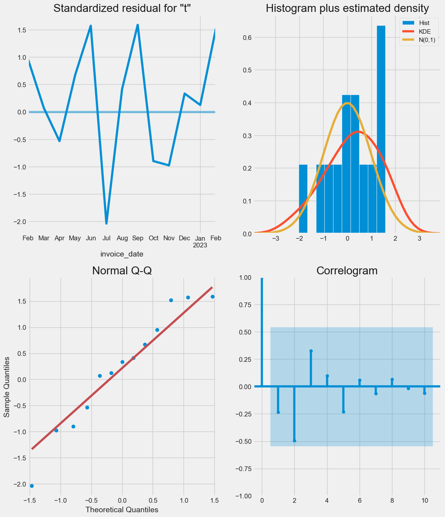

```python
# run model diagnostics to investigate any unusual behavior
results.plot_diagnostics(figsize=(12, 15))
fig.tight_layout()
plt.show()
```

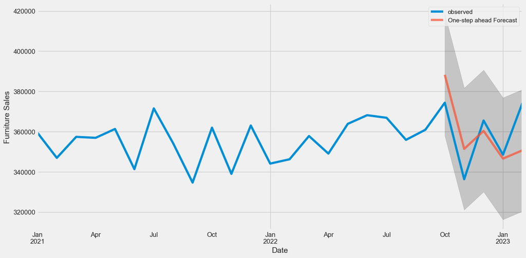

```python
# plot forecasts value along with true values
pred = results.get_prediction(start=pd.to_datetime('2022-10-01'), dynamic=False)
pred_ci = pred.conf_int()
ax = total_sales['2021':].plot(label='observed')
pred.predicted_mean.plot(ax=ax, label='One-step ahead Forecast', alpha=.7, figsize=(14, 7))
ax.fill_between(pred_ci.index,
                pred_ci.iloc[:, 0],
                pred_ci.iloc[:, 1], color='k', alpha=.2)
ax.set_xlabel('Date')
ax.set_ylabel('Furniture Sales')
plt.legend()
plt.show()
```

```python
# calculate MSE and RMSE
total_sales_forecasted = pred.predicted_mean
total_sales_truth = total_sales['2021-01-01':]

# MSE
mse = ((total_sales_forecasted - total_sales_truth) ** 2).mean()

print('The Mean Squared Error of our forecasts is {}'.format(round(mse, 2)))
print('The Root Mean Squared Error of our forecasts is {}'.format(round(np.sqrt(mse), 2)))
```

```
The Mean Squared Error of our forecasts is 200823186.91
The Root Mean Squared Error of our forecasts is 14171.21
```

[figure not shown]

```python
# visualize forecasted values for the reminder of 2023
pred_uc = results.get_forecast(steps=11)
pred_ci = pred_uc.conf_int()
ax = total_sales.plot(label='observed', figsize=(14, 7))
pred_uc.predicted_mean.plot(ax=ax, label='Forecast')
ax.fill_between(pred_ci.index,
                pred_ci.iloc[:, 0],
                pred_ci.iloc[:, 1], color='k', alpha=.25)
ax.set_xlabel('Date')
ax.set_ylabel('Total Sales')
plt.legend()
plt.show()
```

```python
# forecasted sales value for Istanbul's shopping market
pred_uc.predicted_mean
```

```
2023-03-01    385743.450657
2023-04-01    376996.835119
2023-05-01    391797.182592
2023-06-01    396109.032119
2023-07-01    394810.533237
2023-08-01    383830.893237
2023-09-01    388858.874452
2023-10-01    402315.337753
2023-11-01    364229.251786
2023-12-01    393458.682592
2024-01-01    376443.001302
Freq: MS, Name: predicted_mean, dtype: float64
```